title: “K-Means-Iris” author: “Mandy” date: “2015.11.3”

## Does k-means work well for classifying this dataset? Does scaling help?

```
##   Sepal.Length Sepal.Width Petal.Length Petal.Width Species
## 1          5.1         3.5          1.4         0.2  setosa
## 2          4.9         3.0          1.4         0.2  setosa
## 3          4.7         3.2          1.3         0.2  setosa
## 4          4.6         3.1          1.5         0.2  setosa
## 5          5.0         3.6          1.4         0.2  setosa
## 6          5.4         3.9          1.7         0.4  setosa
```

```r
# choosing number of clusters
require("NbClust")
nc <- NbClust(irisnew, min.nc=2, max.nc=15, method="kmeans")
```

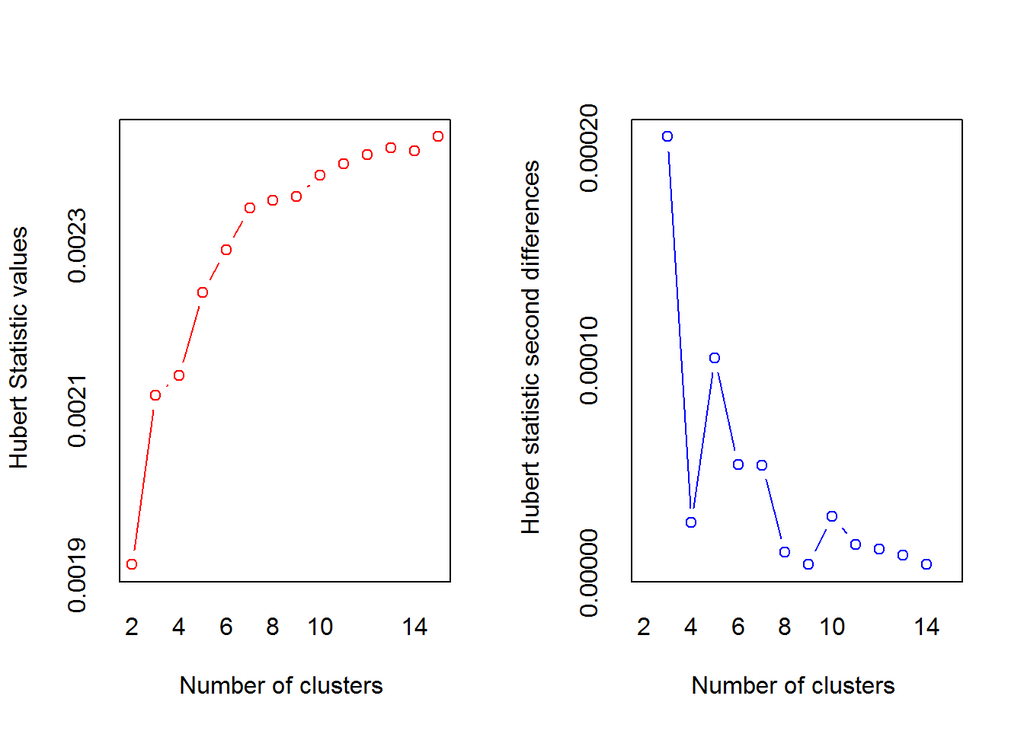

```
## *** : The Hubert index is a graphical method of determining the number of clusters.
##                 In the plot of Hubert index, we seek a significant knee that corresponds to a
##                 significant increase of the value of the measure i.e the significant peak in Hubert
##                 index second differences plot.
##
```

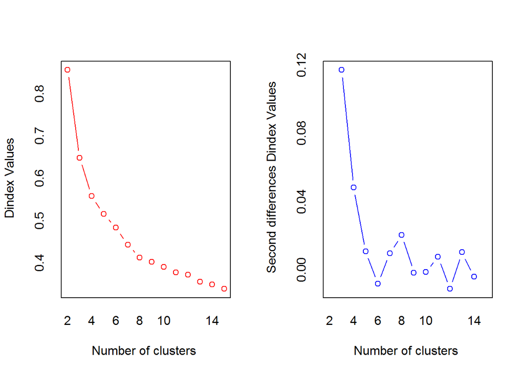

```
## *** : The D index is a graphical method of determining the number of clusters.
##                 In the plot of D index, we seek a significant knee (the significant peak in Dindex
##                 second differences plot) that corresponds to a significant increase of the value of
##                 the measure.
##
## * Among all indices:
## * 10 proposed 2 as the best number of clusters
## * 8 proposed 3 as the best number of clusters
## * 2 proposed 4 as the best number of clusters
## * 1 proposed 5 as the best number of clusters
## * 1 proposed 8 as the best number of clusters
## * 1 proposed 14 as the best number of clusters
## * 1 proposed 15 as the best number of clusters
##
##                    ***** Conclusion *****
##
## * According to the majority rule, the best number of clusters is  2
##
##
```

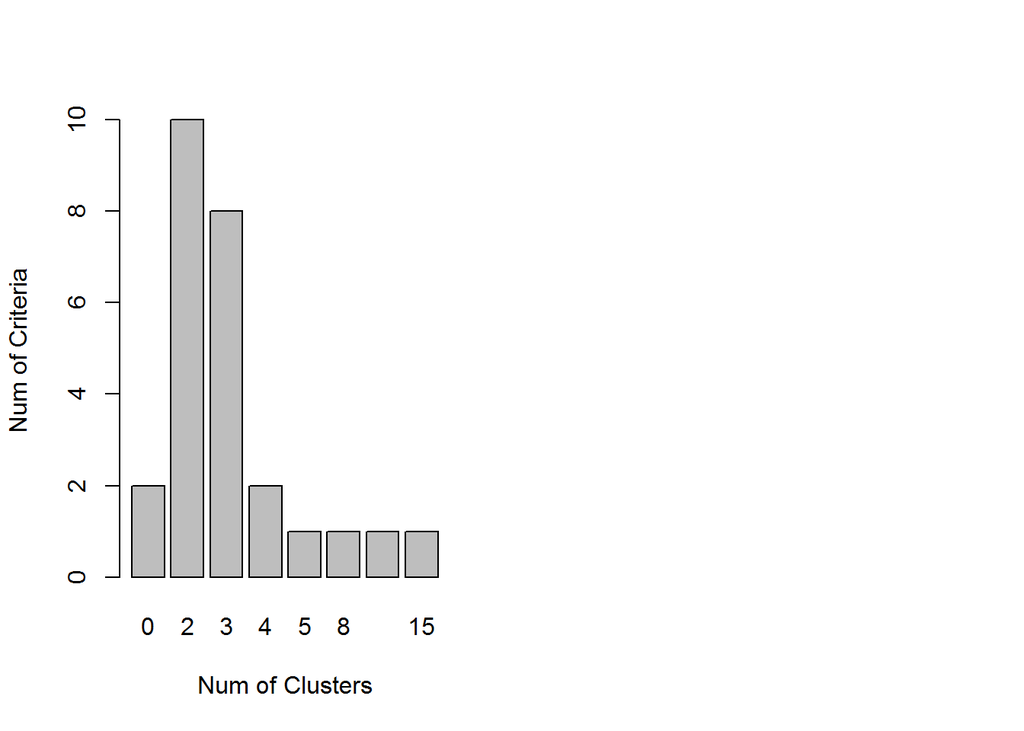

```r
barplot(table(nc$Best.n[1,]),xlab="Num of Clusters", ylab="Num of Criteria")
```

We could see from the plot that 2 clusters are the best. This also agrees with the barplot results with 2 clusters being supported the most by 10 indicies. However, 3 clusters are the second suggested one with 8 proposed indices.

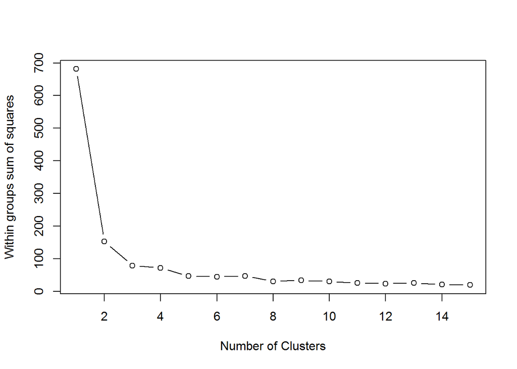

```r
wss <- 0
for (i in 1:15){
  wss[i] <-sum(kmeans(irisnew, centers=i)$withinss)
}
plot(1:15,wss,type="b", xlab="Number of Clusters", ylab="Within groups sum of squares")
```

The sum of square error (SSE) screen plot also shows that cluster=2 is the significant bend. Both methods suggest k=2 is the best, but as there are 3 types in iris, we continue to try 2 and 3 clusters respectively.

```r
fit.kmiris2 <- kmeans(irisnew,2)
fit.kmiris2
```

```
## K-means clustering with 2 clusters of sizes 97, 53
##
## Cluster means:
##   Sepal.Length Sepal.Width Petal.Length Petal.Width
## 1     6.301031    2.886598     4.958763    1.695876
## 2     5.005660    3.369811     1.560377    0.290566
##
## Clustering vector:
##   [1] 2 2 2 2 2 2 2 2 2 2 2 2 2 2 2 2 2 2 2 2 2 2 2 2 2 2 2 2 2 2 2 2 2 2 2
##  [36] 2 2 2 2 2 2 2 2 2 2 2 2 2 2 2 1 1 1 1 1 1 1 2 1 1 1 1 1 1 1 1 1 1 1 1
##  [71] 1 1 1 1 1 1 1 1 1 1 1 1 1 1 1 1 1 1 1 1 1 1 1 2 1 1 1 1 2 1 1 1 1 1 1
## [106] 1 1 1 1 1 1 1 1 1 1 1 1 1 1 1 1 1 1 1 1 1 1 1 1 1 1 1 1 1 1 1 1 1 1 1
## [141] 1 1 1 1 1 1 1 1 1 1
##
## Within cluster sum of squares by cluster:
## [1] 123.79588  28.55208
##  (between_SS / total_SS =  77.6 %)
##
## Available components:
##
## [1] "cluster"      "centers"      "totss"        "withinss"
## [5] "tot.withinss" "betweenss"    "size"         "iter"
## [9] "ifault"
```

```r
fit.kmiris3 <- kmeans(irisnew,3)
fit.kmiris3
```

```
## K-means clustering with 3 clusters of sizes 62, 50, 38
##
## Cluster means:
##   Sepal.Length Sepal.Width Petal.Length Petal.Width
## 1     5.901613    2.748387     4.393548    1.433871
## 2     5.006000    3.428000     1.462000    0.246000
## 3     6.850000    3.073684     5.742105    2.071053
##
## Clustering vector:
##   [1] 2 2 2 2 2 2 2 2 2 2 2 2 2 2 2 2 2 2 2 2 2 2 2 2 2 2 2 2 2 2 2 2 2 2 2
##  [36] 2 2 2 2 2 2 2 2 2 2 2 2 2 2 2 1 1 3 1 1 1 1 1 1 1 1 1 1 1 1 1 1 1 1 1
##  [71] 1 1 1 1 1 1 1 3 1 1 1 1 1 1 1 1 1 1 1 1 1 1 1 1 1 1 1 1 1 1 3 1 3 3 3
## [106] 3 1 3 3 3 3 3 3 1 1 3 3 3 3 1 3 1 3 1 3 3 1 1 3 3 3 3 3 1 3 3 3 3 1 3
## [141] 3 3 1 3 3 3 1 3 3 1
##
## Within cluster sum of squares by cluster:
## [1] 39.82097 15.15100 23.87947
##  (between_SS / total_SS =  88.4 %)
##
## Available components:
##
## [1] "cluster"      "centers"      "totss"        "withinss"
## [5] "tot.withinss" "betweenss"    "size"         "iter"
## [9] "ifault"
```

```r
library(fpc)
```

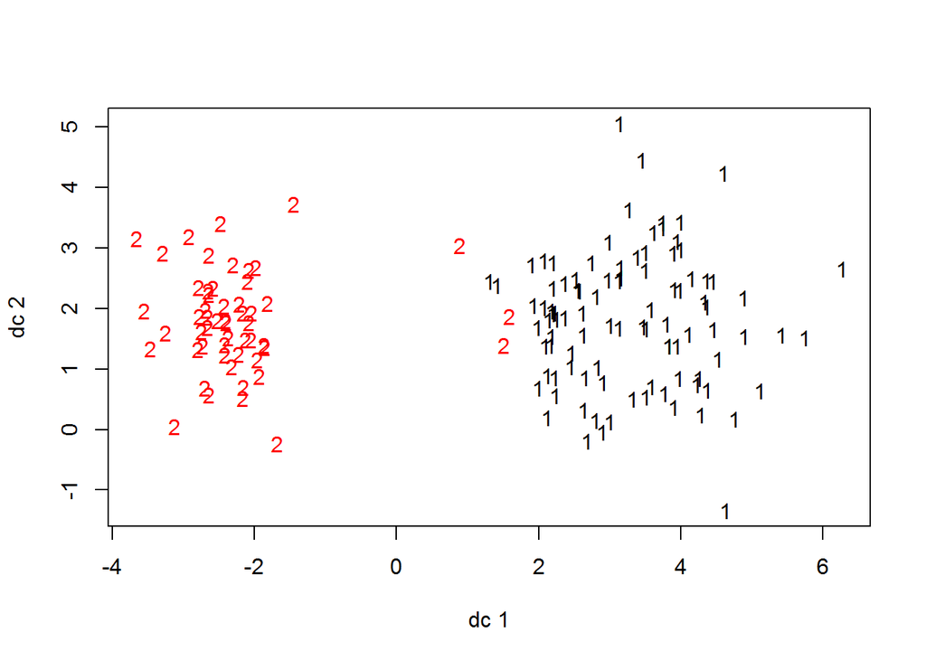

```r
plotcluster(irisnew, fit.kmiris2$cluster)
```

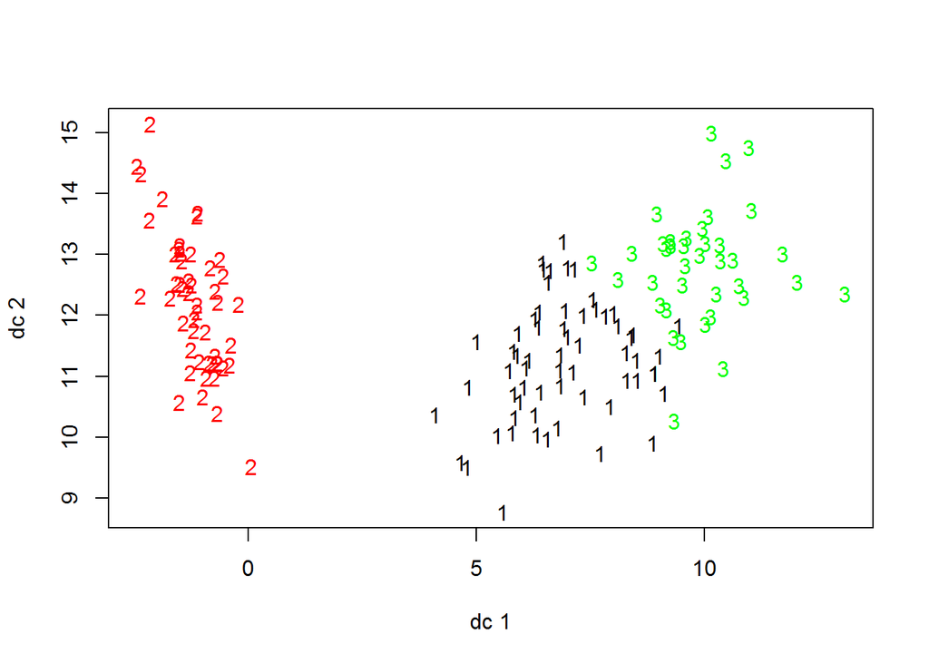

```r
plotcluster(irisnew, fit.kmiris3$cluster)
```

when cluster=2, (between_SS / total_SS = 77.6 %) thus the overall difference is very large between groups. Also, there are almost no collapse between clusters, but there are 3 data points in group 2 very close to group 1.  
When cluster=3, (between_SS / total_SS = 88.4 %) yields a better difference across groups. There is some collapse between group1 and 3 but overall it makes more sense because it’s more like the real case.  
Also, it’s noticeable that the two clustering numbers give very different results.

```r
a=table(iris$Species,fit.kmiris2$cluster)
b=table(iris$Species,fit.kmiris3$cluster)
a
```

```
##
##               1  2
##   setosa      0 50
##   versicolor 47  3
##   virginica  50  0
```

```r
b
```

```
##
##               1  2  3
##   setosa      0 50  0
##   versicolor 48  0  2
##   virginica  14  0 36
```

```r
library(flexclust)
randIndex(a)
```

```
##       ARI
## 0.5399218
```

```r
randIndex(b)
```

```
##       ARI
## 0.7302383
```

A small ARI indicates a poor classification.  
When cluster=2, ARI is only 0.54, which is conceivable because there are only 2 clusters compared to the original 3 groups.  
When cluster=3, ARI is 0.73, which is still not satisfatory so I continue to scale the data.

```r
nc <- NbClust(scale(iris[-5]), min.nc=2, max.nc=15, method="kmeans")
```

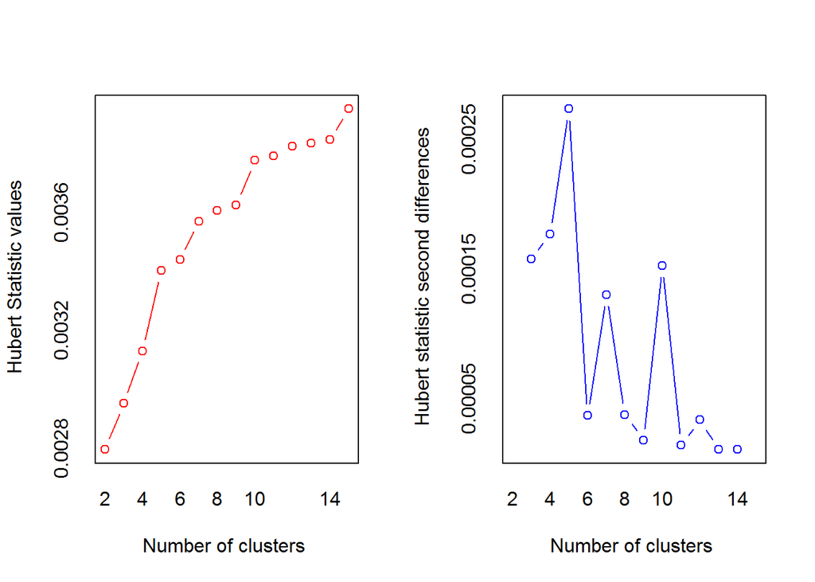

```
## *** : The Hubert index is a graphical method of determining the number of clusters.
##                 In the plot of Hubert index, we seek a significant knee that corresponds to a
##                 significant increase of the value of the measure i.e the significant peak in Hubert
##                 index second differences plot.
##
```

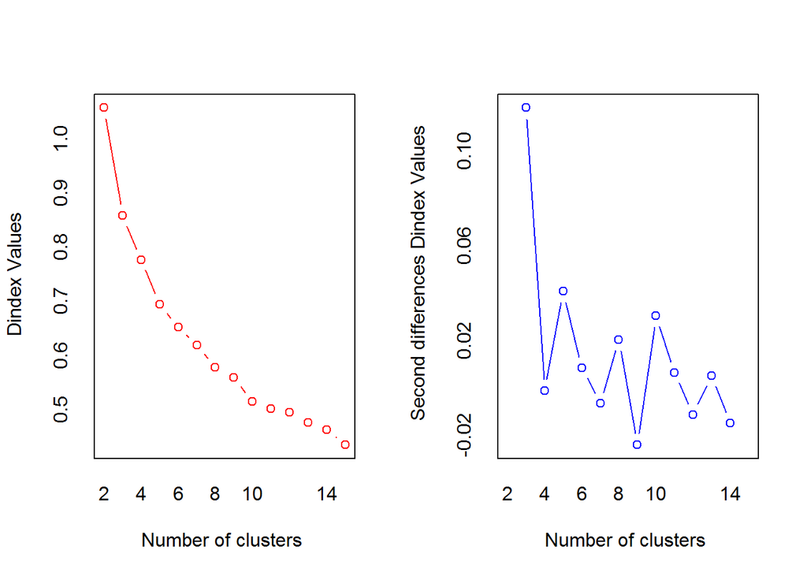

```
## *** : The D index is a graphical method of determining the number of clusters.
##                 In the plot of D index, we seek a significant knee (the significant peak in Dindex
##                 second differences plot) that corresponds to a significant increase of the value of
##                 the measure.
##
## * Among all indices:
## * 8 proposed 2 as the best number of clusters
## * 10 proposed 3 as the best number of clusters
## * 1 proposed 5 as the best number of clusters
## * 2 proposed 10 as the best number of clusters
## * 3 proposed 15 as the best number of clusters
##
##                    ***** Conclusion *****
##
## * According to the majority rule, the best number of clusters is  3
##
##
```

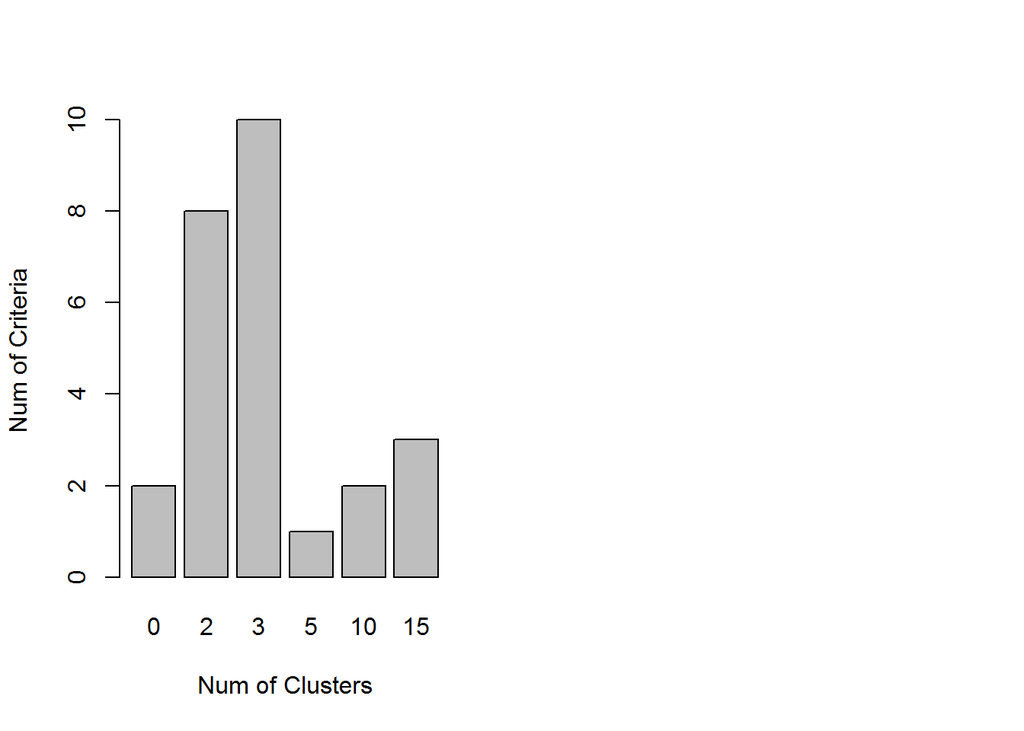

```r
barplot(table(nc$Best.n[1,]),xlab="Num of Clusters", ylab="Num of Criteria")
```

After scaling, the two methods all suggest cluster number to be 3.

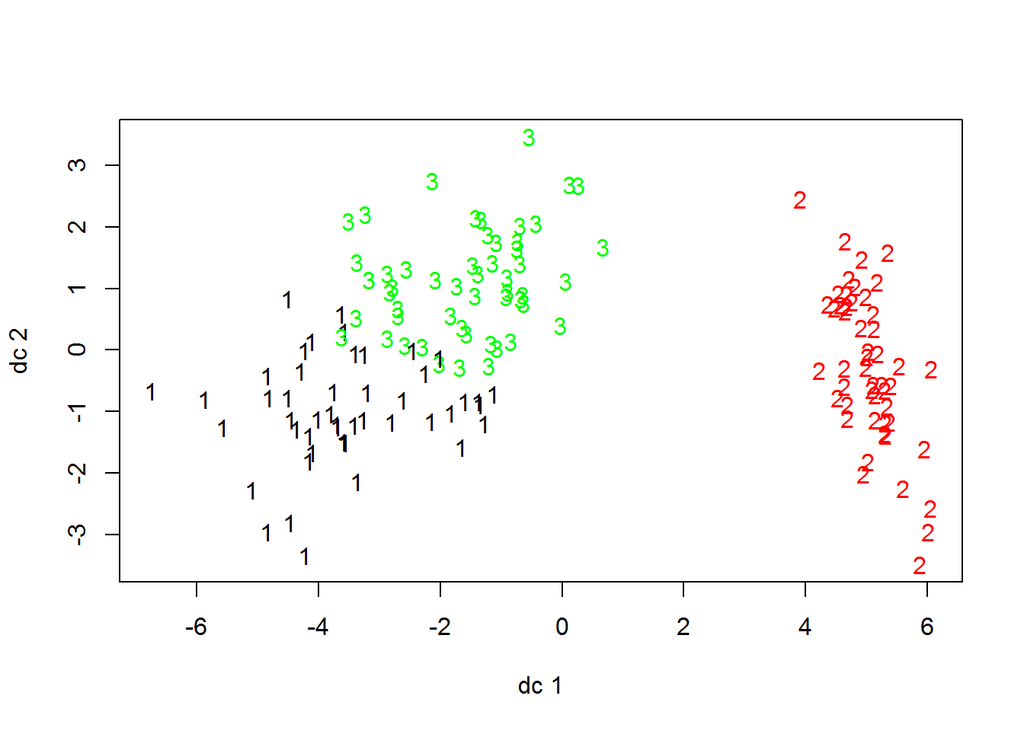

```r
fit2=kmeans(scale(iris[-5]),3)
plotcluster(scale(iris[-5]), fit2$cluster)
```

The plot looks like the unscaled plot with cluster=3, however the boundary is even more blur.

```r
c=table(iris$Species,fit2$cluster)
library(flexclust)
randIndex(c)
```

```
##       ARI
## 0.6201352
```

After scaling, ARI drops to 0.62. K-means seems not a good classfication method for iris and the scaling doesn’t help. It is because the predictor in iris are similar in terms of sacle.